# Table of Contents

**Kernel Author:**  
[Bhishan Poudel, Data Scientist, Ph.D Astrophysics](https://bhishanpdl.github.io/) .

# Data Description

This dataset contains house sale prices for King County, which includes Seattle. It includes homes sold between May 2014 and May 2015.

- Dependent features: 1 (price)
- Features : 19 home features
- Id: 1 house ID

Task: Estimate the price based on given features.

Notes:

- For some reasons bathrooms are float like 1.5, 1.75, we can make them integer.

[figure not shown]

# Imports

```python
# my custom module
import bhishan
import src
%load_ext autoreload
%autoreload 2
```

```python
import numpy as np
import pandas as pd
import seaborn as sns
sns.set(color_codes=True)

import matplotlib
import matplotlib.pyplot as plt
%matplotlib inline

import os
import time
import collections
import itertools

# random state
random_state=100
np.random.seed(random_state) # we need this in each cell
np.random.set_state=random_state

# Jupyter notebook settings for pandas
pd.set_option('display.max_columns', 200)
pd.set_option('display.float_format', '{:,.3f}'.format) # numbers sep by comma
pd.set_option('display.max_rows', 100) # None for all the rows
pd.set_option('display.max_colwidth', 200)

print([(x.__name__,x.__version__) for x in [np, pd,sns,matplotlib]])

from IPython.display import display, HTML
```

```
[('numpy', '1.16.4'), ('pandas', '0.25.0'), ('seaborn', '0.9.0'), ('matplotlib', '3.1.1')]
```

```python
import plotly
import plotly.offline as py
import plotly.graph_objs as go
import plotly.figure_factory as ff
import plotly.tools as tls
from plotly.offline import plot, iplot, init_notebook_mode
init_notebook_mode(connected=False)

print([(x.__name__,x.__version__) for x in [plotly]])
```

```
[('plotly', '3.10.0')]
```

```python
import statsmodels
import statsmodels.api as sm
import statsmodels.formula.api as smf
```

```python
import sklearn
print([(x.__name__,x.__version__) for x in [statsmodels, sklearn]])
```

```
[('statsmodels', '0.10.1'), ('sklearn', '0.21.2')]
```

```python
# scale and split
from sklearn.model_selection import train_test_split
```

```python
# regressor preprocessing
from sklearn.preprocessing import StandardScaler
from sklearn.preprocessing import PolynomialFeatures
```

```python
# regressors
from sklearn import linear_model
from sklearn.linear_model import LinearRegression
from sklearn.neighbors import KNeighborsRegressor
from sklearn.ensemble import RandomForestRegressor
```

```python
# grid search
from sklearn.model_selection import GridSearchCV
```

```python
# metrics
from sklearn import metrics
from sklearn import utils
from sklearn.metrics import mean_squared_error
```

```python
# cross validation
from sklearn.model_selection import cross_val_score

df_eval = pd.DataFrame({'Model': [],
                           'Details':[],
                           'Root Mean Squared Error (RMSE)':[],
                           'R-squared (training)':[],
                           'Adjusted R-squared (training)':[],
                           'R-squared (test)':[],
                           'Adjusted R-squared (test)':[],
                           '5-Fold Cross Validation':[]})
```

```python
def adjustedR2(rsquared,nrows,kcols):
    return rsquared- (kcols-1)/(nrows-kcols) * (1-rsquared)
```

# Load the data

```python
df_raw = pd.read_csv("../data/raw/kc_house_data.csv")
print(df_raw.shape)

df = df_raw.copy(deep=True)
df_raw.head()
```

```
(21613, 21)
```

|  | id | date | price | bedrooms | bathrooms | sqft_living | sqft_lot | floors | waterfront | view | condition | grade | sqft_above | sqft_basement | yr_built | yr_renovated | zipcode | lat | long | sqft_living15 | sqft_lot15 |
| --- | --- | --- | --- | --- | --- | --- | --- | --- | --- | --- | --- | --- | --- | --- | --- | --- | --- | --- | --- | --- | --- |
| 0 | 7129300520 | 20141013T000000 | 221,900.000 | 3 | 1.000 | 1180 | 5650 | 1.000 | 0 | 0 | 3 | 7 | 1180 | 0 | 1955 | 0 | 98178 | 47.511 | -122.257 | 1340 | 5650 |
| 1 | 6414100192 | 20141209T000000 | 538,000.000 | 3 | 2.250 | 2570 | 7242 | 2.000 | 0 | 0 | 3 | 7 | 2170 | 400 | 1951 | 1991 | 98125 | 47.721 | -122.319 | 1690 | 7639 |
| 2 | 5631500400 | 20150225T000000 | 180,000.000 | 2 | 1.000 | 770 | 10000 | 1.000 | 0 | 0 | 3 | 6 | 770 | 0 | 1933 | 0 | 98028 | 47.738 | -122.233 | 2720 | 8062 |
| 3 | 2487200875 | 20141209T000000 | 604,000.000 | 4 | 3.000 | 1960 | 5000 | 1.000 | 0 | 0 | 5 | 7 | 1050 | 910 | 1965 | 0 | 98136 | 47.521 | -122.393 | 1360 | 5000 |
| 4 | 1954400510 | 20150218T000000 | 510,000.000 | 3 | 2.000 | 1680 | 8080 | 1.000 | 0 | 0 | 3 | 8 | 1680 | 0 | 1987 | 0 | 98074 | 47.617 | -122.045 | 1800 | 7503 |

```python
from bhishan.util_ds import get_column_descriptions

get_column_descriptions(df)
```

Dataframe Description

|  | column | dtype | nans | nunique | nzeros |
| --- | --- | --- | --- | --- | --- |
| 0 | id | int64 | 0 | 21436 | 0 |
| 1 | bedrooms | int64 | 0 | 13 | 13 |
| 2 | sqft_living | int64 | 0 | 1038 | 0 |
| 3 | sqft_lot | int64 | 0 | 9782 | 0 |
| 4 | waterfront | int64 | 0 | 2 | 21450 |
| 5 | view | int64 | 0 | 5 | 19489 |
| 6 | condition | int64 | 0 | 5 | 0 |
| 7 | grade | int64 | 0 | 12 | 0 |
| 8 | sqft_above | int64 | 0 | 946 | 0 |
| 9 | sqft_basement | int64 | 0 | 306 | 13126 |
| 10 | yr_built | int64 | 0 | 116 | 0 |
| 11 | yr_renovated | int64 | 0 | 70 | 20699 |
| 12 | zipcode | int64 | 0 | 70 | 0 |
| 13 | sqft_living15 | int64 | 0 | 777 | 0 |
| 14 | sqft_lot15 | int64 | 0 | 8689 | 0 |
| 15 | price | float64 | 0 | 4028 | 0 |
| 16 | bathrooms | float64 | 0 | 30 | 10 |
| 17 | floors | float64 | 0 | 6 | 0 |
| 18 | lat | float64 | 0 | 5034 | 0 |
| 19 | long | float64 | 0 | 752 | 0 |
| 20 | date | object | 0 | 372 | 0 |

# Feature Selection

> bedrooms, bathrooms, floors, waterfront, view, condition, grade are categorical columns but we can also use them as numerical columns to see how to model performs.

> lat and long are geo coordinates, they are also categorical and sometimes treated as numerical data.

> basement = living - above is redundant variable, may be used or not. This is just a choice of feature engineering.

> year columns can be converted to age columns and ages can be binned, however, they also can be treated as number and used in the model.

> features with large values can be log1p transformed.

> outliers can be removed from the features.

```python
df.dtypes
```

```
id                 int64
date              object
price            float64
bedrooms           int64
bathrooms        float64
sqft_living        int64
sqft_lot           int64
floors           float64
waterfront         int64
view               int64
condition          int64
grade              int64
sqft_above         int64
sqft_basement      int64
yr_built           int64
yr_renovated       int64
zipcode            int64
lat              float64
long             float64
sqft_living15      int64
sqft_lot15         int64
dtype: object
```

```python
df.head()
```

|  | id | date | price | bedrooms | bathrooms | sqft_living | sqft_lot | floors | waterfront | view | condition | grade | sqft_above | sqft_basement | yr_built | yr_renovated | zipcode | lat | long | sqft_living15 | sqft_lot15 |
| --- | --- | --- | --- | --- | --- | --- | --- | --- | --- | --- | --- | --- | --- | --- | --- | --- | --- | --- | --- | --- | --- |
| 0 | 7129300520 | 20141013T000000 | 221,900.000 | 3 | 1.000 | 1180 | 5650 | 1.000 | 0 | 0 | 3 | 7 | 1180 | 0 | 1955 | 0 | 98178 | 47.511 | -122.257 | 1340 | 5650 |
| 1 | 6414100192 | 20141209T000000 | 538,000.000 | 3 | 2.250 | 2570 | 7242 | 2.000 | 0 | 0 | 3 | 7 | 2170 | 400 | 1951 | 1991 | 98125 | 47.721 | -122.319 | 1690 | 7639 |
| 2 | 5631500400 | 20150225T000000 | 180,000.000 | 2 | 1.000 | 770 | 10000 | 1.000 | 0 | 0 | 3 | 6 | 770 | 0 | 1933 | 0 | 98028 | 47.738 | -122.233 | 2720 | 8062 |
| 3 | 2487200875 | 20141209T000000 | 604,000.000 | 4 | 3.000 | 1960 | 5000 | 1.000 | 0 | 0 | 5 | 7 | 1050 | 910 | 1965 | 0 | 98136 | 47.521 | -122.393 | 1360 | 5000 |
| 4 | 1954400510 | 20150218T000000 | 510,000.000 | 3 | 2.000 | 1680 | 8080 | 1.000 | 0 | 0 | 3 | 8 | 1680 | 0 | 1987 | 0 | 98074 | 47.617 | -122.045 | 1800 | 7503 |

```python
df.columns
```

```
Index(['id', 'date', 'price', 'bedrooms', 'bathrooms', 'sqft_living',
       'sqft_lot', 'floors', 'waterfront', 'view', 'condition', 'grade',
       'sqft_above', 'sqft_basement', 'yr_built', 'yr_renovated', 'zipcode',
       'lat', 'long', 'sqft_living15', 'sqft_lot15'],
      dtype='object')
```

```python
features_raw_all = ['bedrooms', 'bathrooms', 'sqft_living',
       'sqft_lot', 'floors', 'waterfront', 'view', 'condition', 'grade',
       'sqft_above', 'sqft_basement', 'yr_built', 'yr_renovated', 'zipcode',
       'lat', 'long', 'sqft_living15', 'sqft_lot15']
```

```python
cols_cat = ['bedrooms', 'bathrooms', 'floors', 'waterfront', 'view',
            'condition', 'grade','zipcode']
```

```python
df.filter(items=cols_cat).apply(pd.Series.nunique)
```

```
bedrooms      13
bathrooms     30
floors         6
waterfront     2
view           5
condition      5
grade         12
zipcode       70
dtype: int64
```

## Make categorical columns numeric (later maybe string and encoding)

```python
df.isnull().sum().sum()
```

```
0
```

```python
for col in cols_cat:
    df[col] = df[col].astype('int32')

df.dtypes
```

```
id                 int64
date              object
price            float64
bedrooms           int32
bathrooms          int32
sqft_living        int64
sqft_lot           int64
floors             int32
waterfront         int32
view               int32
condition          int32
grade              int32
sqft_above         int64
sqft_basement      int64
yr_built           int64
yr_renovated       int64
zipcode            int32
lat              float64
long             float64
sqft_living15      int64
sqft_lot15         int64
dtype: object
```

```python
df.isnull().sum().sum()
```

```
0
```

# Check for outliers

```python
with pd.option_context('display.max_colwidth', 500):
    display(df[cols_cat].apply(
        lambda x: str(pd.Series.unique(x).tolist()) ).to_frame())
```

|  | 0 |
| --- | --- |
| bedrooms | [3, 2, 4, 5, 1, 6, 7, 0, 8, 9, 11, 10, 33] |
| bathrooms | [1, 2, 3, 4, 0, 5, 6, 8, 7] |
| floors | [1, 2, 3] |
| waterfront | [0, 1] |
| view | [0, 3, 4, 2, 1] |
| condition | [3, 5, 4, 1, 2] |
| grade | [7, 6, 8, 11, 9, 5, 10, 12, 4, 3, 13, 1] |
| zipcode | [98178, 98125, 98028, 98136, 98074, 98053, 98003, 98198, 98146, 98038, 98007, 98115, 98107, 98126, 98019, 98103, 98002, 98133, 98040, 98092, 98030, 98119, 98112, 98052, 98027, 98117, 98058, 98001, 980… |

```python
def freq_count(df1, nlargest=None):
    """ Return the item frequency tuple for each unique elements of columns."""
    vals = df1.values.T
    tmp = [ collections.Counter(vals[i]).most_common(nlargest) for i in range(len(vals)) ]
    df_freq = pd.DataFrame(np.array(tmp).T,
                           columns=['item_frequency_tuple'],
                           index=df1.columns)
    return df_freq


cols_cat_small = ['bedrooms', 'bathrooms', 'floors', 'waterfront',
                  'view', 'condition', 'grade']

dftmp = df[cols_cat_small]

freq_count(dftmp)
```

|  | item_frequency_tuple |
| --- | --- |
| bedrooms | [(3, 9824), (4, 6882), (2, 2760), (5, 1601), (6, 272), (1, 199), (7, 38), (0, 13), (8, 13), (9, 6), (10, 3), (11, 1), (33, 1)] |
| bathrooms | [(2, 10542), (1, 8355), (3, 2228), (4, 338), (0, 86), (5, 48), (6, 12), (8, 2), (7, 2)] |
| floors | [(1, 12590), (2, 8402), (3, 621)] |
| waterfront | [(0, 21450), (1, 163)] |
| view | [(0, 19489), (2, 963), (3, 510), (1, 332), (4, 319)] |
| condition | [(3, 14031), (4, 5679), (5, 1701), (2, 172), (1, 30)] |
| grade | [(7, 8981), (8, 6068), (9, 2615), (6, 2038), (10, 1134), (11, 399), (5, 242), (12, 90), (4, 29), (13, 13), (3, 3), (1, 1)] |

```python
len(df)
```

```
21613
```

```python
# suspected outliers
# bedrooms 10, 11, 33
# bathrooms 8,7
# grade 3,1
```

```python
df = df.drop(df[df["bedrooms"]>=10].index )
df = df.drop(df[df["bathrooms"]>=7].index )
df = df.drop(df[df["grade"].isin([3,1])].index )

df[cols_cat_small].apply(
        lambda x: str(pd.Series.unique(x).tolist())
).to_frame()
```

|  | 0 |
| --- | --- |
| bedrooms | [3, 2, 4, 5, 1, 6, 7, 0, 8, 9] |
| bathrooms | [1, 2, 3, 4, 0, 5, 6] |
| floors | [1, 2, 3] |
| waterfront | [0, 1] |
| view | [0, 3, 4, 2, 1] |
| condition | [3, 5, 4, 1, 2] |
| grade | [7, 6, 8, 11, 9, 5, 10, 12, 4, 13] |

```python
df.isnull().sum().sum()
```

```
0
```

```python
# backup clean data
df_no_outliers = df.copy(deep=True)
```

```python
features = ['bedrooms', 'bathrooms', 'sqft_living',
            'sqft_lot', 'grade', 'sqft_above',
            'sqft_basement', 'yr_built', 'zipcode',
            'lat', 'long','sqft_living15', 'sqft_lot15']

target = ['price']

df = df[features + target]
df.head(2)
```

|  | bedrooms | bathrooms | sqft_living | sqft_lot | grade | sqft_above | sqft_basement | yr_built | zipcode | lat | long | sqft_living15 | sqft_lot15 | price |
| --- | --- | --- | --- | --- | --- | --- | --- | --- | --- | --- | --- | --- | --- | --- |
| 0 | 3 | 1 | 1180 | 5650 | 7 | 1180 | 0 | 1955 | 98178 | 47.511 | -122.257 | 1340 | 5650 | 221,900.000 |
| 1 | 3 | 2 | 2570 | 7242 | 7 | 2170 | 400 | 1951 | 98125 | 47.721 | -122.319 | 1690 | 7639 | 538,000.000 |

# Scaling

```python
df.isnull().sum().sum()
```

```
0
```

```python
from sklearn.preprocessing import StandardScaler

ss = StandardScaler()

# we must reset index if we have removed outliers
df = df.reset_index(drop=True)
array_scaled_feat = ss.fit_transform(df.drop('price',axis=1))
df_feat = pd.DataFrame(array_scaled_feat, columns = features)
df = pd.concat([df_feat, df[target]], axis=1)
```

```python
df.isnull().any(axis=1).sum()
```

```
0
```

# Check multi-collinearity using eigen values

If eigen value is close to zero, we may drop the feature.

```python
df_corr = df.corr()
eigen_values, eigen_vectors = np.linalg.eig(df_corr)
print(eigen_values.round(3))
```

```
[ 5.25   2.159  1.552  1.087  0.841  0.646  0.688  0.441  0.38   0.288
  0.262  0.212  0.196 -0.   ]
```

```python
df_corr.sort_values('price').round(2).style.background_gradient()
```

|  | bedrooms | bathrooms | sqft_living | sqft_lot | grade | sqft_above | sqft_basement | yr_built | zipcode | lat | long | sqft_living15 | sqft_lot15 | price |
| --- | --- | --- | --- | --- | --- | --- | --- | --- | --- | --- | --- | --- | --- | --- |
| zipcode | -0.16 | -0.16 | -0.2 | -0.13 | -0.19 | -0.26 | 0.08 | -0.35 | 1 | 0.27 | -0.56 | -0.28 | -0.15 | -0.05 |
| long | 0.14 | 0.18 | 0.24 | 0.23 | 0.2 | 0.35 | -0.15 | 0.41 | -0.56 | -0.14 | 1 | 0.34 | 0.25 | 0.02 |
| yr_built | 0.16 | 0.44 | 0.32 | 0.05 | 0.45 | 0.43 | -0.13 | 1 | -0.35 | -0.15 | 0.41 | 0.33 | 0.07 | 0.06 |
| sqft_lot15 | 0.03 | 0.08 | 0.18 | 0.72 | 0.12 | 0.19 | 0.01 | 0.07 | -0.15 | -0.09 | 0.25 | 0.18 | 1 | 0.08 |
| sqft_lot | 0.03 | 0.08 | 0.17 | 1 | 0.11 | 0.18 | 0.01 | 0.05 | -0.13 | -0.09 | 0.23 | 0.14 | 0.72 | 0.09 |
| lat | -0.01 | 0.03 | 0.05 | -0.09 | 0.11 | -0 | 0.11 | -0.15 | 0.27 | 1 | -0.14 | 0.05 | -0.09 | 0.31 |
| bedrooms | 1 | 0.48 | 0.59 | 0.03 | 0.37 | 0.49 | 0.31 | 0.16 | -0.16 | -0.01 | 0.14 | 0.4 | 0.03 | 0.32 |
| sqft_basement | 0.31 | 0.25 | 0.43 | 0.01 | 0.17 | -0.06 | 1 | -0.13 | 0.08 | 0.11 | -0.15 | 0.2 | 0.01 | 0.32 |
| bathrooms | 0.48 | 1 | 0.69 | 0.08 | 0.61 | 0.64 | 0.25 | 0.44 | -0.16 | 0.03 | 0.18 | 0.51 | 0.08 | 0.51 |
| sqft_living15 | 0.4 | 0.51 | 0.76 | 0.14 | 0.71 | 0.73 | 0.2 | 0.33 | -0.28 | 0.05 | 0.34 | 1 | 0.18 | 0.59 |
| sqft_above | 0.49 | 0.64 | 0.88 | 0.18 | 0.76 | 1 | -0.06 | 0.43 | -0.26 | -0 | 0.35 | 0.73 | 0.19 | 0.6 |
| grade | 0.37 | 0.61 | 0.76 | 0.11 | 1 | 0.76 | 0.17 | 0.45 | -0.19 | 0.11 | 0.2 | 0.71 | 0.12 | 0.67 |
| sqft_living | 0.59 | 0.69 | 1 | 0.17 | 0.76 | 0.88 | 0.43 | 0.32 | -0.2 | 0.05 | 0.24 | 0.76 | 0.18 | 0.7 |
| price | 0.32 | 0.51 | 0.7 | 0.09 | 0.67 | 0.6 | 0.32 | 0.06 | -0.05 | 0.31 | 0.02 | 0.59 | 0.08 | 1 |

# Missing Values

```python
df.isnull().sum().sum()
```

```
0
```

# Train test split

```python
from sklearn.model_selection import train_test_split

train, test = train_test_split(df, test_size=0.3, random_state=100)

df.shape, train.shape, test.shape
```

```
((21600, 14), (15120, 14), (6480, 14))
```

# Simple Linear Regression

```python
feature = 'sqft_living'
target = 'price'

X = df[feature].values.reshape(-1,1)
y = df[target].values.reshape(-1,1)

Xtrain = train[feature].values.reshape(-1,1)
ytrain = train[target].values.reshape(-1,1)

Xtest = test[feature].values.reshape(-1,1)
ytest = test[target].values.reshape(-1,1)
```

```python
lr = LinearRegression()
lr.fit(Xtrain, ytrain)
```

```
LinearRegression(copy_X=True, fit_intercept=True, n_jobs=None, normalize=False)
```

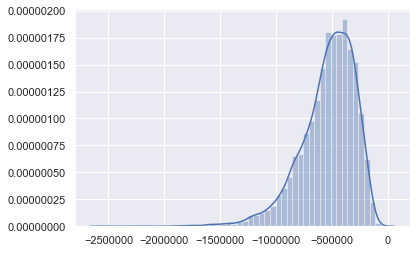

```python
ypreds = lr.predict(Xtest)
resids = Xtest - ypreds

sns.distplot(resids) # residual should be normal curve for linear regression.
```

```python
rmse = np.sqrt(mean_squared_error(ytest,ypreds)).round(3)
r2_train = lr.score(Xtrain, ytrain).round(3)
r2_test = lr.score(Xtest, ytest).round(3)

cv = cross_val_score(lr, X, y, cv=5).mean().round(3)
```

```python
df_eval.loc[len(df_eval)] = ['Simple Linear Regression',
                             'living space vs price, living area has highest correlation',
                             rmse,r2_train,r2_train,r2_test,r2_test,cv]

df_eval
```

|  | Model | Details | Root Mean Squared Error (RMSE) | R-squared (training) | Adjusted R-squared (training) | R-squared (test) | Adjusted R-squared (test) | 5-Fold Cross Validation |
| --- | --- | --- | --- | --- | --- | --- | --- | --- |
| 0 | Simple Linear Regression | living space vs price, living area has highest correlation | 251,320.957 | 0.497 | 0.497 | 0.470 | 0.470 | 0.487 |

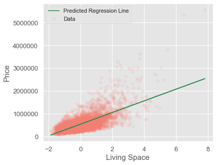

```python
from bhishan.util_model_plot import plot_simple_linear_regression
plot_simple_linear_regression(Xtest, ytest, lr,"Living Space",'Price')
```

# Multiple Linear Regression

```python
def multiple_linear_regression(df,features,target,model,cv=5):
    """ Multiple Linear Regression Modelling using given model.

    Depends:
    Depends on function adjusted r-squared.


    Returns:
    rmse, r2_train, ar2_train, r2_test, ar2_test, cv
    """

    # train test values
    X = df[features].values
    y = df[target].values.reshape(-1,1)

    Xtrain = train[features].values
    ytrain = train[target].values.reshape(-1,1)

    Xtest = test[features].values
    ytest = test[target].values.reshape(-1,1)

    # random forest regressor wants 0d scalar not 1d vector
    if isinstance(model, sklearn.ensemble.RandomForestRegressor):
        ytrain = train[target].values.ravel()

    # fitting
    model.fit(Xtrain,ytrain)

    # prediction
    ypreds = model.predict(Xtest)

    # metrics
    rmse = np.sqrt(mean_squared_error(ytest,ypreds)).round(3)
    r2_train = model.score(Xtrain, ytrain).round(3)
    r2_test = model.score(Xtest, ytest).round(3)

    cv = cross_val_score(model, X, y, cv=5,n_jobs=-1,verbose=1).mean().round(3)

    ar2_train = adjustedR2(model.score(Xtrain,ytrain),
                           Xtrain.shape[0],
                           len(features)).round(3)
    ar2_test  = adjustedR2(model.score(Xtest,ytest),
                           Xtest.shape[0] ,
                           len(features)).round(3)

    return (rmse, r2_train, ar2_train, r2_test, ar2_test, cv)
```

```python
features = ['bedrooms', 'bathrooms', 'sqft_living',
            'sqft_lot', 'grade', 'sqft_above',
            'sqft_basement', 'yr_built', 'zipcode',
            'lat', 'long','sqft_living15', 'sqft_lot15']

target = ['price']
model = linear_model.LinearRegression()

rmse, r2_train, ar2_train, r2_test, ar2_test, cv = \
    multiple_linear_regression(df, features, target,model)


df_eval.loc[len(df_eval)] = ['Multiple Linear Regression',
                             'all features, some features made integer, outliers removed, scaled',
                    rmse,r2_train,ar2_train,r2_test,ar2_test,cv]

df_eval.sort_values('Adjusted R-squared (test)')
```

```
[Parallel(n_jobs=-1)]: Using backend LokyBackend with 4 concurrent workers.
[Parallel(n_jobs=-1)]: Done   5 out of   5 | elapsed:    1.6s finished
```

|  | Model | Details | Root Mean Squared Error (RMSE) | R-squared (training) | Adjusted R-squared (training) | R-squared (test) | Adjusted R-squared (test) | 5-Fold Cross Validation |
| --- | --- | --- | --- | --- | --- | --- | --- | --- |
| 0 | Simple Linear Regression | living space vs price, living area has highest correlation | 251,320.957 | 0.497 | 0.497 | 0.470 | 0.470 | 0.487 |
| 1 | Multiple Linear Regression | all features, some features made integer, outliers removed, scaled | 202,401.138 | 0.665 | 0.665 | 0.656 | 0.656 | 0.660 |

# Backward Elimination

```python
df.head(2)
```

|  | bedrooms | bathrooms | sqft_living | sqft_lot | grade | sqft_above | sqft_basement | yr_built | zipcode | lat | long | sqft_living15 | sqft_lot15 | price |
| --- | --- | --- | --- | --- | --- | --- | --- | --- | --- | --- | --- | --- | --- | --- |
| 0 | -0.408 | -1.026 | -0.987 | -0.228 | -0.561 | -0.738 | -0.660 | -0.545 | 1.870 | -0.353 | -0.306 | -0.944 | -0.261 | 221,900.000 |
| 1 | -0.408 | 0.344 | 0.540 | -0.190 | -0.561 | 0.465 | 0.247 | -0.681 | 0.879 | 1.162 | -0.746 | -0.433 | -0.188 | 538,000.000 |

```python
df.columns
```

```
Index(['bedrooms', 'bathrooms', 'sqft_living', 'sqft_lot', 'grade',
       'sqft_above', 'sqft_basement', 'yr_built', 'zipcode', 'lat', 'long',
       'sqft_living15', 'sqft_lot15', 'price'],
      dtype='object')
```

```python
features_all = ['bedrooms', 'bathrooms', 'sqft_living', 'sqft_lot', 'grade',
       'sqft_above', 'sqft_basement', 'yr_built', 'zipcode', 'lat', 'long',
       'sqft_living15', 'sqft_lot15']

formula = 'price ~ ' + '+'.join(features_all)
formula
```

```
'price ~ bedrooms+bathrooms+sqft_living+sqft_lot+grade+sqft_above+sqft_basement+yr_built+zipcode+lat+long+sqft_living15+sqft_lot15'
```

```python
model = smf.ols(formula=formula, data=df)
model_fit = model.fit()

model_fit.summary()
```

OLS Regression Results

| Dep. Variable: | price | R-squared: | 0.663 |
| --- | --- | --- | --- |
| Model: | OLS | Adj. R-squared: | 0.663 |
| Method: | Least Squares | F-statistic: | 3538. |
| Date: | Sat, 28 Sep 2019 | Prob (F-statistic): | 0.00 |
| Time: | 21:46:47 | Log-Likelihood: | -2.9532e+05 |
| No. Observations: | 21600 | AIC: | 5.907e+05 |
| Df Residuals: | 21587 | BIC: | 5.908e+05 |
| Df Model: | 12 |  |  |
| Covariance Type: | nonrobust |  |  |

|  | coef | std err | t | P>\|t\| | [0.025 | 0.975] |
| --- | --- | --- | --- | --- | --- | --- |
| Intercept | 5.394e+05 | 1427.167 | 377.958 | 0.000 | 5.37e+05 | 5.42e+05 |
| bedrooms | -4.208e+04 | 1833.296 | -22.955 | 0.000 | -4.57e+04 | -3.85e+04 |
| bathrooms | 4.018e+04 | 2136.085 | 18.812 | 0.000 | 3.6e+04 | 4.44e+04 |
| sqft_living | 8.343e+04 | 1634.240 | 51.050 | 0.000 | 8.02e+04 | 8.66e+04 |
| sqft_lot | 6117.2138 | 2065.194 | 2.962 | 0.003 | 2069.281 | 1.02e+04 |
| grade | 1.23e+05 | 2612.184 | 47.076 | 0.000 | 1.18e+05 | 1.28e+05 |
| sqft_above | 7.213e+04 | 1704.148 | 42.328 | 0.000 | 6.88e+04 | 7.55e+04 |
| sqft_basement | 3.756e+04 | 1424.153 | 26.374 | 0.000 | 3.48e+04 | 4.04e+04 |
| yr_built | -9.156e+04 | 1869.968 | -48.964 | 0.000 | -9.52e+04 | -8.79e+04 |
| zipcode | -2.786e+04 | 1811.349 | -15.381 | 0.000 | -3.14e+04 | -2.43e+04 |
| lat | 7.593e+04 | 1533.902 | 49.504 | 0.000 | 7.29e+04 | 7.89e+04 |
| long | -3.46e+04 | 1917.236 | -18.049 | 0.000 | -3.84e+04 | -3.08e+04 |
| sqft_living15 | 2.871e+04 | 2418.276 | 11.873 | 0.000 | 2.4e+04 | 3.35e+04 |
| sqft_lot15 | -8341.8837 | 2081.121 | -4.008 | 0.000 | -1.24e+04 | -4262.733 |

| Omnibus: | 17499.470 | Durbin-Watson: | 1.991 |
| --- | --- | --- | --- |
| Prob(Omnibus): | 0.000 | Jarque-Bera (JB): | 1129707.460 |
| Skew: | 3.445 | Prob(JB): | 0.00 |
| Kurtosis: | 37.753 | Cond. No. | 9.92e+15 |

Warnings:  
[1] Standard Errors assume that the covariance matrix of the errors is correctly specified.  
[2] The smallest eigenvalue is 1.05e-27. This might indicate that there are  
strong multicollinearity problems or that the design matrix is singular.

```python
from bhishan.util_statsmodels import print_statsmodels_summary

print_statsmodels_summary(model_fit.summary())
```

OLS Regression Results

| Dep. Variable: | price | R-squared: | 0.663 |
| --- | --- | --- | --- |
| Model: | OLS | Adj. R-squared: | 0.663 |
| Method: | Least Squares | F-statistic: | 3538. |
| Date: | Sat, 28 Sep 2019 | Prob (F-statistic): | 0.00 |
| Time: | 21:46:47 | Log-Likelihood: | -2.9532e+05 |
| No. Observations: | 21600 | AIC: | 5.907e+05 |
| Df Residuals: | 21587 | BIC: | 5.908e+05 |
| Df Model: | 12 |  |  |
| Covariance Type: | nonrobust |  |  |

|  | coef | std err | t | P>\|t\| | [0.025 | 0.975] |
| --- | --- | --- | --- | --- | --- | --- |
| Intercept | 5.394e+05 | 1427.167 | 377.958 | 0.000 | 5.37e+05 | 5.42e+05 |
| bedrooms | -4.208e+04 | 1833.296 | -22.955 | 0.000 | -4.57e+04 | -3.85e+04 |
| bathrooms | 4.018e+04 | 2136.085 | 18.812 | 0.000 | 3.6e+04 | 4.44e+04 |
| sqft_living | 8.343e+04 | 1634.240 | 51.050 | 0.000 | 8.02e+04 | 8.66e+04 |
| sqft_lot | 6117.2138 | 2065.194 | 2.962 | 0.003 | 2069.281 | 1.02e+04 |
| grade | 1.23e+05 | 2612.184 | 47.076 | 0.000 | 1.18e+05 | 1.28e+05 |
| sqft_above | 7.213e+04 | 1704.148 | 42.328 | 0.000 | 6.88e+04 | 7.55e+04 |
| sqft_basement | 3.756e+04 | 1424.153 | 26.374 | 0.000 | 3.48e+04 | 4.04e+04 |
| yr_built | -9.156e+04 | 1869.968 | -48.964 | 0.000 | -9.52e+04 | -8.79e+04 |
| zipcode | -2.786e+04 | 1811.349 | -15.381 | 0.000 | -3.14e+04 | -2.43e+04 |
| lat | 7.593e+04 | 1533.902 | 49.504 | 0.000 | 7.29e+04 | 7.89e+04 |
| long | -3.46e+04 | 1917.236 | -18.049 | 0.000 | -3.84e+04 | -3.08e+04 |
| sqft_living15 | 2.871e+04 | 2418.276 | 11.873 | 0.000 | 2.4e+04 | 3.35e+04 |
| sqft_lot15 | -8341.8837 | 2081.121 | -4.008 | 0.000 | -1.24e+04 | -4262.733 |

| Omnibus: | 17499.470 | Durbin-Watson: | 1.991 |
| --- | --- | --- | --- |
| Prob(Omnibus): | 0.000 | Jarque-Bera (JB): | 1129707.460 |
| Skew: | 3.445 | Prob(JB): | 0.00 |
| Kurtosis: | 37.753 | Cond. No. | 9.92e+15 |

Warnings:  
[1] Standard Errors assume that the covariance matrix of the errors is correctly specified.  
[2] The smallest eigenvalue is 1.05e-27. This might indicate that there are  
strong multicollinearity problems or that the design matrix is singular.

```python
def show_method_attributes(method, ncols=2):
    """ Show all the attributes of a given method.
    Example:
    ========
    show_method_attributes(list)
     """
    x = [I for I in dir(method) if I[0].islower()]
    x = [I for I in x if I not in 'os np pd sys time psycopg2'.split()]

    return pd.DataFrame(np.array_split(x,ncols)).T.fillna('')
```

```python
show_method_attributes(model_fit,7)
```

|  | 0 | 1 | 2 | 3 | 4 | 5 | 6 |
| --- | --- | --- | --- | --- | --- | --- | --- |
| 0 | aic | conf_int_el | df_resid | get_influence | mse_resid | resid | t_test |
| 1 | bic | cov_HC0 | diagn | get_prediction | mse_total | resid_pearson | t_test_pairwise |
| 2 | bse | cov_HC1 | eigenvals | get_robustcov_results | nobs | rsquared | tvalues |
| 3 | centered_tss | cov_HC2 | el_test | initialize | normalized_cov_params | rsquared_adj | uncentered_tss |
| 4 | compare_f_test | cov_HC3 | ess | k_constant | outlier_test | save | use_t |
| 5 | compare_lm_test | cov_kwds | f_pvalue | llf | params | scale | wald_test |
| 6 | compare_lr_test | cov_params | f_test | load | predict | ssr | wald_test_terms |
| 7 | condition_number | cov_type | fittedvalues | model | pvalues | summary | wresid |
| 8 | conf_int | df_model | fvalue | mse_model | remove_data | summary2 |  |

```python
model_fit.pvalues
```

```
Intercept       0.000
bedrooms        0.000
bathrooms       0.000
sqft_living     0.000
sqft_lot        0.003
grade           0.000
sqft_above      0.000
sqft_basement   0.000
yr_built        0.000
zipcode         0.000
lat             0.000
long            0.000
sqft_living15   0.000
sqft_lot15      0.000
dtype: float64
```

```python
# I choose significance level alpha = 0.05
# all the p-values are less than 0.05, I will not remove any features.
```

# KNN Regressor

```python
model = KNeighborsRegressor(n_neighbors=1)
rmse, r2_train, ar2_train, r2_test, ar2_test, cv = \
    multiple_linear_regression(df, features, target,model)


df_eval.loc[len(df_eval)] = ['KNN Regressor n_neighbors=1',
                             'all features, some features made integer, outliers removed, scaled',
                    rmse,r2_train,ar2_train,r2_test,ar2_test,cv]

df_eval.sort_values('Adjusted R-squared (test)',ascending=False)
```

```
[Parallel(n_jobs=-1)]: Using backend LokyBackend with 4 concurrent workers.
[Parallel(n_jobs=-1)]: Done   5 out of   5 | elapsed:    1.1s finished
```

|  | Model | Details | Root Mean Squared Error (RMSE) | R-squared (training) | Adjusted R-squared (training) | R-squared (test) | Adjusted R-squared (test) | 5-Fold Cross Validation |
| --- | --- | --- | --- | --- | --- | --- | --- | --- |
| 2 | KNN Regressor n_neighbors=1 | all features, some features made integer, outliers removed, scaled | 193,534.826 | 0.999 | 0.999 | 0.686 | 0.685 | 0.658 |
| 1 | Multiple Linear Regression | all features, some features made integer, outliers removed, scaled | 202,401.138 | 0.665 | 0.665 | 0.656 | 0.656 | 0.660 |
| 0 | Simple Linear Regression | living space vs price, living area has highest correlation | 251,320.957 | 0.497 | 0.497 | 0.470 | 0.470 | 0.487 |

```python
from sklearn.model_selection import GridSearchCV
```

```python
# usually people do odd number grid search upto np.sqrt(len(df))
# but for simplicity I will check only 50 neighbors.
```

```python
k_range = list(range(1,50,2))
weight_options = ["uniform", "distance"]

param_grid = dict(n_neighbors = k_range, weights = weight_options)
knn = KNeighborsRegressor()

grid = GridSearchCV(knn, param_grid, cv = 10, scoring = 'neg_mean_squared_error' ,n_jobs=-1)
grid.fit(X,y)
```

```
GridSearchCV(cv=10, error_score='raise-deprecating',
             estimator=KNeighborsRegressor(algorithm='auto', leaf_size=30,
                                           metric='minkowski',
                                           metric_params=None, n_jobs=None,
                                           n_neighbors=5, p=2,
                                           weights='uniform'),
             iid='warn', n_jobs=-1,
             param_grid={'n_neighbors': [1, 3, 5, 7, 9, 11, 13, 15, 17, 19, 21,
                                         23, 25, 27, 29, 31, 33, 35, 37, 39, 41,
                                         43, 45, 47, 49],
                         'weights': ['uniform', 'distance']},
             pre_dispatch='2*n_jobs', refit=True, return_train_score=False,
             scoring='neg_mean_squared_error', verbose=0)
```

```python
grid.best_params_
```

```
{'n_neighbors': 49, 'weights': 'uniform'}
```

```python
model = KNeighborsRegressor(n_neighbors= 49, weights= 'uniform')

rmse, r2_train, ar2_train, r2_test, ar2_test, cv = \
    multiple_linear_regression(df, features, target,model)


df_eval.loc[len(df_eval)] = ['KNN Regressor n_neighbors=49 after grid search',
                             'all features, some features made integer, outliers removed, scaled',
                    rmse,r2_train,ar2_train,r2_test,ar2_test,cv]

df_eval.sort_values('Adjusted R-squared (test)',ascending=False)
```

```
[Parallel(n_jobs=-1)]: Using backend LokyBackend with 4 concurrent workers.
[Parallel(n_jobs=-1)]: Done   5 out of   5 | elapsed:    3.5s finished
```

|  | Model | Details | Root Mean Squared Error (RMSE) | R-squared (training) | Adjusted R-squared (training) | R-squared (test) | Adjusted R-squared (test) | 5-Fold Cross Validation |
| --- | --- | --- | --- | --- | --- | --- | --- | --- |
| 3 | KNN Regressor n_neighbors=49 after grid search | all features, some features made integer, outliers removed, scaled | 168,995.231 | 0.768 | 0.768 | 0.760 | 0.760 | 0.760 |
| 2 | KNN Regressor n_neighbors=1 | all features, some features made integer, outliers removed, scaled | 193,534.826 | 0.999 | 0.999 | 0.686 | 0.685 | 0.658 |
| 1 | Multiple Linear Regression | all features, some features made integer, outliers removed, scaled | 202,401.138 | 0.665 | 0.665 | 0.656 | 0.656 | 0.660 |
| 0 | Simple Linear Regression | living space vs price, living area has highest correlation | 251,320.957 | 0.497 | 0.497 | 0.470 | 0.470 | 0.487 |

# Random Forest Regressor

```python
from sklearn.ensemble import RandomForestRegressor
```

```python
model = RandomForestRegressor(n_estimators= 1)

rmse, r2_train, ar2_train, r2_test, ar2_test, cv = \
    multiple_linear_regression(df, features, target,model)


df_eval.loc[len(df_eval)] = ['Random Forest Regressor n_estimators=1',
                             'all features, some features made integer, outliers removed, scaled',
                    rmse,r2_train,ar2_train,r2_test,ar2_test,cv]

df_eval.sort_values('Adjusted R-squared (test)',ascending=False)
```

```
[Parallel(n_jobs=-1)]: Using backend LokyBackend with 4 concurrent workers.
[Parallel(n_jobs=-1)]: Done   5 out of   5 | elapsed:    0.3s finished
```

|  | Model | Details | Root Mean Squared Error (RMSE) | R-squared (training) | Adjusted R-squared (training) | R-squared (test) | Adjusted R-squared (test) | 5-Fold Cross Validation |
| --- | --- | --- | --- | --- | --- | --- | --- | --- |
| 3 | KNN Regressor n_neighbors=49 after grid search | all features, some features made integer, outliers removed, scaled | 168,995.231 | 0.768 | 0.768 | 0.760 | 0.760 | 0.760 |
| 2 | KNN Regressor n_neighbors=1 | all features, some features made integer, outliers removed, scaled | 193,534.826 | 0.999 | 0.999 | 0.686 | 0.685 | 0.658 |
| 1 | Multiple Linear Regression | all features, some features made integer, outliers removed, scaled | 202,401.138 | 0.665 | 0.665 | 0.656 | 0.656 | 0.660 |
| 4 | Random Forest Regressor n_estimators=1 | all features, some features made integer, outliers removed, scaled | 202,261.788 | 0.872 | 0.872 | 0.657 | 0.656 | 0.667 |
| 0 | Simple Linear Regression | living space vs price, living area has highest correlation | 251,320.957 | 0.497 | 0.497 | 0.470 | 0.470 | 0.487 |

```python
model = RandomForestRegressor(n_estimators= 49)

rmse, r2_train, ar2_train, r2_test, ar2_test, cv = \
    multiple_linear_regression(df, features, target,model)


df_eval.loc[len(df_eval)] = ['Random Forest Regressor n_estimators=49',
                             'all features, some features made integer, outliers removed, scaled',
                    rmse,r2_train,ar2_train,r2_test,ar2_test,cv]

df_eval.sort_values('Adjusted R-squared (test)',ascending=False)
```

```
[Parallel(n_jobs=-1)]: Using backend LokyBackend with 4 concurrent workers.
[Parallel(n_jobs=-1)]: Done   5 out of   5 | elapsed:   19.9s finished
```

|  | Model | Details | Root Mean Squared Error (RMSE) | R-squared (training) | Adjusted R-squared (training) | R-squared (test) | Adjusted R-squared (test) | 5-Fold Cross Validation |
| --- | --- | --- | --- | --- | --- | --- | --- | --- |
| 5 | Random Forest Regressor n_estimators=49 | all features, some features made integer, outliers removed, scaled | 136,023.422 | 0.976 | 0.976 | 0.845 | 0.844 | 0.845 |
| 3 | KNN Regressor n_neighbors=49 after grid search | all features, some features made integer, outliers removed, scaled | 168,995.231 | 0.768 | 0.768 | 0.760 | 0.760 | 0.760 |
| 2 | KNN Regressor n_neighbors=1 | all features, some features made integer, outliers removed, scaled | 193,534.826 | 0.999 | 0.999 | 0.686 | 0.685 | 0.658 |
| 1 | Multiple Linear Regression | all features, some features made integer, outliers removed, scaled | 202,401.138 | 0.665 | 0.665 | 0.656 | 0.656 | 0.660 |
| 4 | Random Forest Regressor n_estimators=1 | all features, some features made integer, outliers removed, scaled | 202,261.788 | 0.872 | 0.872 | 0.657 | 0.656 | 0.667 |
| 0 | Simple Linear Regression | living space vs price, living area has highest correlation | 251,320.957 | 0.497 | 0.497 | 0.470 | 0.470 | 0.487 |